# Aplicación de técnicas de aprendizaje no supervisado sobre datos biológicos

Pedro Manuel Rodríguez Santos

Noviembre 2025

# **Objetivo**

La finalidad de esta actividad es determinar de forma justificada aquellos algoritmos de aprendizaje no supervisado más eficientes a la hora de detectar patrones en el conjunto de datos propuesto mediante la aplicación R y el conjunto de datos de RNA-seq de cáncer de mama. Para ello, se van a implementar cuatro técnicas de aprendizaje no supervisado con métodos de reducción de la dimensionalidad.

## Método 1. Principal component analysis (PCA).

Los aspectos positivos de PCA es que elimina las correlaciones entre las variables que poseen alta correlación para mejorar la independencia de los datos y poder explicar la mayor variabilidad posible, pudiendo visualizar los datos de una forma más clara y precisa.

Entre los inconvenientes está que debe existir una relación lineal entre las variables con una proporción constante y que necesita procesos de estandarización de los datos previo para generar correctamente las componentes principales que expliquen la mayor variabilidad posible.

Para poder realizar el análisis, se ha tenido que solucionar una serie de dificultades en el conjunto de datos para poder ejecutarlo. Se ha explorado la existencia de valores NA y 0, y de datos incorrectos que puedan encontrarse en el archivo “data.csv”. No se han detectado valores NA, pero si se han encontrado valores 0, que pueden ser por errores en la toma de datos o porque son genes que no se han expresado, y, debido a esta ultima posible circunstancia, se cuenta con ellos para realizar el análisis. En la primera columna hay datos que son caracteres de texto y no numéricos, por lo que se han tenido que eliminar para poder desarrollar el código. También se han detectado outliers al realizar PCA que se mantienen en el gráfico para su evaluación.

```r
# Directorio en donde tendremos nuestros datos

setwd("F:/UNIVERSIDAD/UNIR/BIOINFORMATICA/Algoritmos/ACTIVIDAD1")

# Carga de librerias

library(stats)   # librería para el PCA
library(ggplot2) # librería para hacer la representación gráfica

# Lectura de datos

data.red <- read.csv('data.csv')
labels.raw <- read.csv('labels.csv')

# Eliminamos la primera columna del archivo

data.raw <- data.red [, -1]

# Guardado en un dataframe de todos los genes

data <- data.frame(sapply(data.raw, as.numeric))

# Se extraen las primeras 10 columnas y se genera un resumen estadístico

summary(data[, 1:10])
```

```
##      gene_0            gene_1          gene_2          gene_3
##  Min.   :0.00000   Min.   :0.000   Min.   :0.000   Min.   : 5.009
##  1st Qu.:0.00000   1st Qu.:2.299   1st Qu.:2.390   1st Qu.: 6.303
##  Median :0.00000   Median :3.144   Median :3.127   Median : 6.656
##  Mean   :0.02664   Mean   :3.011   Mean   :3.095   Mean   : 6.722
##  3rd Qu.:0.00000   3rd Qu.:3.883   3rd Qu.:3.803   3rd Qu.: 7.038
##  Max.   :1.48233   Max.   :6.237   Max.   :6.063   Max.   :10.130
##      gene_4           gene_5      gene_6           gene_7
##  Min.   : 8.436   Min.   :0   Min.   : 3.931   Min.   :0.0000
##  1st Qu.: 9.464   1st Qu.:0   1st Qu.: 6.676   1st Qu.:0.0000
##  Median : 9.792   Median :0   Median : 7.450   Median :0.4431
##  Mean   : 9.814   Mean   :0   Mean   : 7.406   Mean   :0.4999
##  3rd Qu.:10.142   3rd Qu.:0   3rd Qu.: 8.122   3rd Qu.:0.7894
##  Max.   :11.356   Max.   :0   Max.   :10.718   Max.   :2.7790
##      gene_8            gene_9
##  Min.   :0.00000   Min.   :0.00000
##  1st Qu.:0.00000   1st Qu.:0.00000
##  Median :0.00000   Median :0.00000
##  Mean   :0.01674   Mean   :0.01343
##  3rd Qu.:0.00000   3rd Qu.:0.00000
##  Max.   :1.78559   Max.   :4.06760
```

```r
# Comprobamos si hay valores NA y 0

anyNA(data)
```

```
## [1] FALSE
```

```r
na_counts <- colSums((is.na(data)))

any(data == 0)
```

```
## [1] TRUE
```

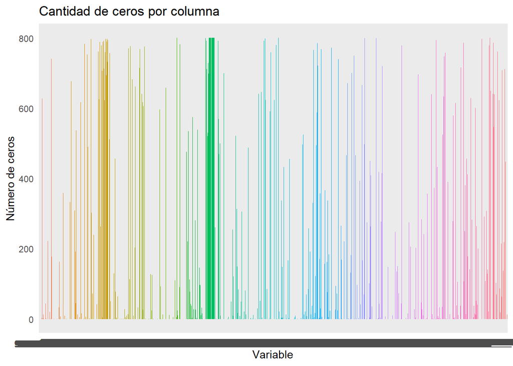

```r
zero_counts <- colSums(data == 0)

# Graficamos los estadísticos

zero_df <- data.frame(
  Variable = names(zero_counts),
  Zeros = as.numeric(zero_counts)
)
ggplot(zero_df, aes(x = Variable, y = Zeros, fill = Variable)) +
  geom_bar(stat = "identity") +
  labs(title = "Cantidad de ceros por columna",
       x = "Variable",
       y = "Número de ceros") +
  theme_minimal() +
  theme(legend.position = "none")  # Oculta la leyenda
```

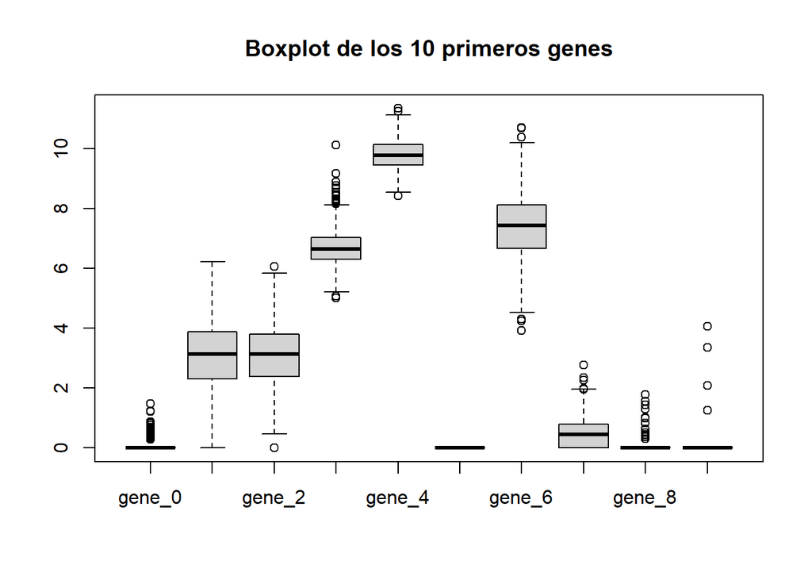

```r
# Se realiza un diagrama de cajas para para las variables y vemos los estadísticos y outliers

boxplot(data[, 1:10], main = "Boxplot de los 10 primeros genes")
```

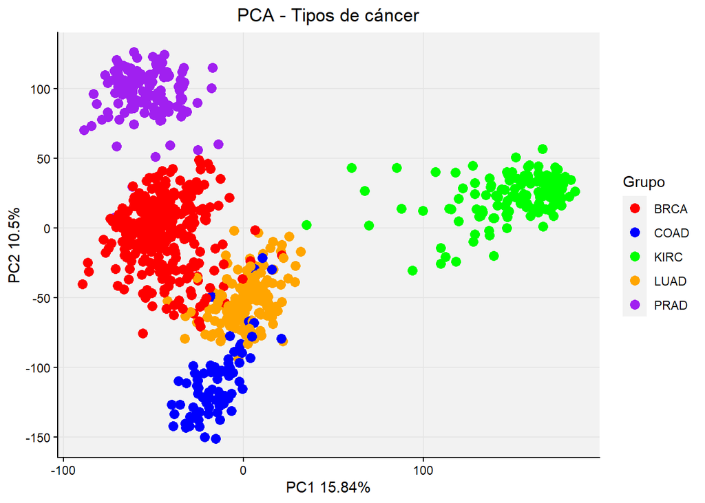

```r
# Funcion prcomp() para realizar PCA
#   data: conjunto de datos
#   center: si queremos que las variables esten centradas en cero
#   scale: si queremos que las variables tengan varianza 1


# Calculo de componentes principales con la funcion prcomp

pca.results <- prcomp(data, center=TRUE, scale.=FALSE)

# Resultado de las componentes principales

pca.df <- data.frame(pca.results$x)

# Varianza (cuadrado de la desviacion tipica)

varianzas <- pca.results$sdev^2

# Total de la varianza de los datos

total.varianza <- sum(varianzas)

# Varianza explicada por cada componente principal

varianza.explicada <- varianzas/total.varianza

# Se calcula la varianza acumulada

varianza.acumulada <- cumsum(varianza.explicada)

# Se toma el numero de componentes principales que explican el 90% de la varianza

n.pc <- min(which(varianza.acumulada > 0.90))

# Etiquetas de los ejes del gráfico

x_label <- paste0(paste('PC1', round(varianza.explicada[1] * 100, 2)), '%')
y_label <- paste0(paste('PC2', round(varianza.explicada[2] * 100, 2)), '%')

# Representación gráfica de las primeras dos componentes principales respecto a los datos

ggplot(pca.df, aes(x=PC1, y=PC2, color=labels.raw$Class)) +
  geom_point(size=3) +
  scale_color_manual(values=c('red', 'blue', 'green', 'orange', 'purple')) +
  labs(title='PCA - Tipos de cáncer', x=x_label, y=y_label, color='Grupo') +
  theme_classic() +
  theme(panel.grid.major = element_line(color="gray90"), panel.grid.minor = element_blank(),
        panel.background = element_rect(fill = "gray95"), plot.title = element_text(hjust = 0.5))
```

El resultado obtenido tiene sentido biológico ya que cada tipo de cáncer tiene diferentes rutas moleculares de activación/inhibición. Se observa que en el eje de variabilidad PC1 diferencia el grupo KIRC respecto a los demás y en el eje PC2 diferencia el grupo PRAD. El resto de grupos (BRCA, LUAD y COAD) también aparecen separados pero más próximos, pudiendo ser más parecidos entre sí respecto al resto y manifestando que que estos tumores pueden comparten vías de señalización.

## Método 2. Multidimensional scaling (MDS)

Para realizar la implementación de MDS, también es necesario el uso de las librerías “stats” y “ggplot2” para generar el gráfico en 2 dimensiones y la librería “plotly” para 3 dimensiones.

El motivo de elegir este algoritmo es poque puede representar estructuras no lineales que dependen de distancias reales entre muestras. Esto es importante porque las variables pueden tener relaciones complejas y depender de perfiles globales, no de correlaciones directas. El MDS los separa gráficamente según su similitud real y es excelente para visualizar estructuras de grupo. Su diferencia con PCA es que se pueden comparar muestras por similaridad absoluta y no solo por la varianza.

Para este análisis se va utilizar la distancia Euclidiana, ya que captura diferencias reales entre perfiles génicos y permite visualizar agrupamientos basados en patrones globales.Además, este método es el más utilizado por los investigadores.

Los aspectos positivos de MDS es que no necesita suposiciones previas sobre lo datos como la independencia o la normalidad de las muestras, y es útil cuando hay pocas variables pero muchas muestras. El MDS métrico es una técnica que conserva las distancias absolutas entre observaciones siendo un método interpretable. El MDS no métrico no conserva esas distancias ya que pueden no ser relevantes debido a que no son distancias reales.

Pero también tiene sus inconvenientes. Es un método muy costoso computacionalmente, y la elección arbitraria de los parámetros durante su implementación puede influir en su resultado final. Además es sensible a los outliers, pudiendo distorsionar el gráfico final. Para poder realizar el análisis se han tenido los mismos problemas que con PCA, por lo que se han tomado las mismas medidas.

**MDS en 2D**

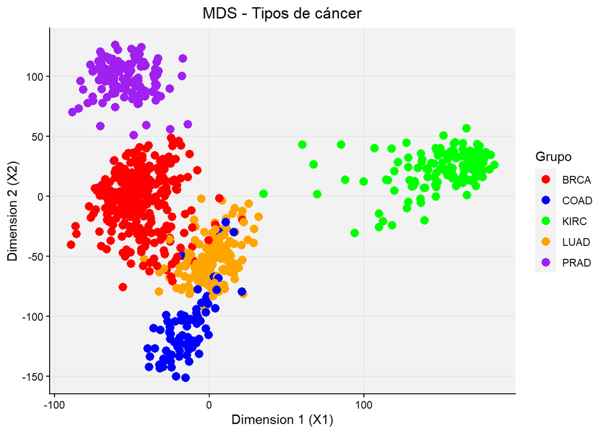

```r
############################
# Multidimensional Scaling #
#############################

# Directorio en donde tendremos nuestros datos

setwd("F:/UNIVERSIDAD/UNIR/BIOINFORMATICA/Algoritmos/ACTIVIDAD1")

# Carga de librerias

library(stats)   # librería para el MDS
library(ggplot2) # librería para hacer la representación gráfica

# Lectura de datos

data.red <- read.csv('data.csv')
labels.raw <- read.csv('labels.csv')

# Eliminamos la primera columna del archivo

data.raw <- data.red [, -1]

# Guardado en un dataframe de los 500 primeros genes

data <- data.frame(sapply(data.raw, as.numeric))

# Algoritmo #

# Funcion cmdscale()
#   d: matriz de distancias (usaremos la funcion dist)
#   k: numero que indica el tamaño final de los datos (max num de variables)
#   eig: si calculamos autovalores de las variables. Nos sirve para el calculo
#        de la varianza explicada, es decir, para coger las columnas de mayor
#        variabilidad
#   x.ret: para devolver la matriz de distancias que calcule el algoritmo

#   points: dataframe de tamaño k que representa las nuevas coordenadas
#   eig: vector con los autovalores para elegir el numero de dimensiones


# Se utiliza la funcion dist para calcular la matriz de distancias euclideas
# matriz NxN de distancias entre todos los puntos

distances <- dist(data, method = 'euclidean')

# Utilizamos la funcon cmdscale para realizar el MSD

mds.results <- cmdscale(distances, eig=TRUE, k=2, x.ret=TRUE)

# Calculamos la varianza explicada

varianza.explicada <- mds.results$eig/sum(mds.results$eig) * 100

# Sacamos en un dataframe los puntos del mds

mds.df <- data.frame(mds.results$points)


# Grafico

ggplot(mds.df, aes(x=X1, y=X2, color=labels.raw$Class)) +
  geom_point(size=3) +
  scale_color_manual(values=c("red", "blue", "green", "orange", "purple")) +
  labs(title="MDS - Tipos de cáncer", x="Dimension 1 (X1)", y="Dimension 2 (X2)",color = "Grupo") +
  theme_classic() +
  theme(panel.grid.major = element_line(color = "gray90"), panel.grid.minor = element_blank(),
        panel.background = element_rect(fill = "gray95"), plot.title=element_text(hjust=0.5))
```

**MDS en 3D**

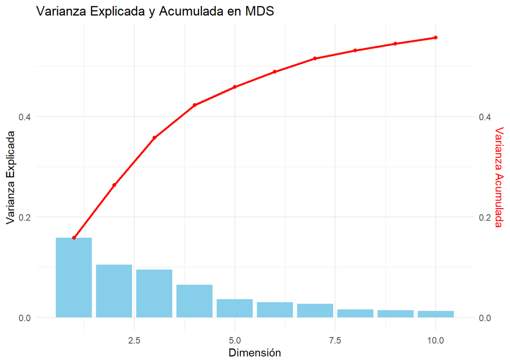

```r
###############################
# Grafico varianza n-dim MDS  #
###############################

# Directorio en donde tendremos nuestros datos

setwd("F:/UNIVERSIDAD/UNIR/BIOINFORMATICA/Algoritmos/ACTIVIDAD1")

# Calcular la matriz de distancias en tus datos

datos <- as.matrix(read.csv("data.csv", row.names = 1))
distancia <- dist(datos)

# Aplicar MDS a un número alto de dimensiones (por ejemplo, 10)

mds_result <- cmdscale(distancia, k = 10, eig = TRUE)

# Calcular la varianza explicada
# La varianza explicada para cada dimensión se calcula usando los valores propios (eigenvalues)

valores_propios <- mds_result$eig
varianza_explicada <- valores_propios / sum(valores_propios)
varianza_acumulada <- cumsum(varianza_explicada)

# Graficar la varianza explicada y la varianza acumulada

library(ggplot2)

# Crear data frame para la gráfica

df_varianza <- data.frame(
  Dimensión = 1:10,
  Varianza_Explicada = varianza_explicada[1:10],
  Varianza_Acumulada = varianza_acumulada[1:10]
)

# Gráfico de varianza explicada

ggplot(df_varianza, aes(x = Dimensión)) +
  geom_bar(aes(y = Varianza_Explicada), stat = "identity", fill = "skyblue") +
  geom_line(aes(y = Varianza_Acumulada), color = "red", size = 1) +
  geom_point(aes(y = Varianza_Acumulada), color = "red") +
  labs(title = "Varianza Explicada y Acumulada en MDS",
       x = "Dimensión",
       y = "Varianza Explicada") +
  theme_minimal() +
  scale_y_continuous(sec.axis = sec_axis(~., name = "Varianza Acumulada")) +
  theme(axis.title.y.right = element_text(color = "red"))
```

```r
###############################
# Multidimensional Scaling 3D #
###############################


# Instalar plotly si no lo tienes instalado
# install.packages("plotly")

library(plotly)
# Supongamos que 'datos' es tu matriz de expresión génica
# Asegúrate de que los datos están en formato numérico y sin columnas de etiquetas

# Calcular la matriz de distancias

distancia <- dist(datos, method = 'euclidean')

# Aplicar MDS a 3 dimensiones

mds_result <- cmdscale(distancia, k = 3)

# Convertir el resultado a un data frame

mds_df <- as.data.frame(mds_result)
colnames(mds_df) <- c("Dim1", "Dim2", "Dim3")

# Añadir etiquetas de cáncer

labels <- read.csv("labels.csv")
mds_df$Cancer_Type <- labels$Class

# Graficar MDS en 3D

fig <- plot_ly(mds_df, x = ~Dim1, y = ~Dim2, z = ~Dim3,
               color = ~Cancer_Type, colors = "Set1",
               marker = list(size = 4))

# Mostrar el gráfico

fig
```

[interactive chart not shown]

Al representar gráficamente las dos primeras variables con MDS (2D), los cinco tipos de cáncer forman grupos diferenciados, aunque con cierta superposición parcial entre algunos de ellos. KIRC y PRAD quedan claramente separadoS del resto, siendo grupos muy distintivos. BCRA queda un poco difuso pero igualmente distinguible. COAD también queda ligeramente separada pero no tan definido. Y LUAD se ubica con una ligera superposición.

La estructura general es muy similar al PCA, lo cual es esperable porque MDS preserva distancias globales, y los datos usados parecen contener patrones lineales. Los grupos aparecen ordenados espacialmente, mostrando que la expresión génica de los diferentes tipos de cáncer es distinta en términos de distancia euclídeas.

Por lo tanto, este resultado también tiene sentido biológico,ya que distintos tipos de cáncer tienen perfiles transcriptómicos muy diferentes, presentando patrones diferenciales bien definidos en la expresión de los genes.

En la representación en 3D se observa de manera más clara la separación entre todos los grupos de tumores, confirmando la diferenciacion génica entre ellos.

## Método 3. T-Distributed Stochastic Neighbor Embedding (t-SNE)

Para realizar la implementación de t-SNE es necesario el uso de las librerías “Rtsne” y “ggplot2”.

El motivo de elegir este algoritmo es que capta relaciones no lineales de combinaciones complejas entre las muestras que no son capturables en un plano lineal. Este método distingue clústeres naturales, ya que esta diseñado para mantener la vecindad local, detectar y separar clústeres reales, y maximizar la distancia entre diferentes grupos. Además, produce visualizaciones altamente interpretables de muestras heterogéneas y con expresión multivariante.

Las ventajas de usar t-SNE es que supera ampliamente a otras técnicas en el manejo eficiente de datos no lineales, ya que capta muy bien las complejas relaciones entre las características. También preserva la localidad de los datos al mismo tiempo que revela parte de la importante estructura global de los datos en el mapeo de baja dimensionalidad. En general es muy eficiente a la hora de identificar la estructura de los datos.

Aunque también tiene sus inconvenientes. Su componente estocástico lo convierte en un método con cierto componente de azar, lo cual afecta a su reproducibilidad: varias ejecuciones del mismo código darán diferentes resultados. Además, es computacionalmente costoso cuando se aplica en conjuntos de datos grandes. Incluso el rendimiento del método para reducir la dimensionalidad de los datos a más de 3 dimensiones no es muy claro, pero es muy recomendado para la visualización de los datos.

Para poder realizar el análisis se han tenido los mismos problemas que con PCA y MDS, por lo que se han tomado las mismas medidas. Además, al seleccionar todos los datos no se ha podido realizar el gráfico, que puede estar debido a los costoso que su implementación, por lo que se ha realizado solo para los primeros 500 genes como se realizó en clase.

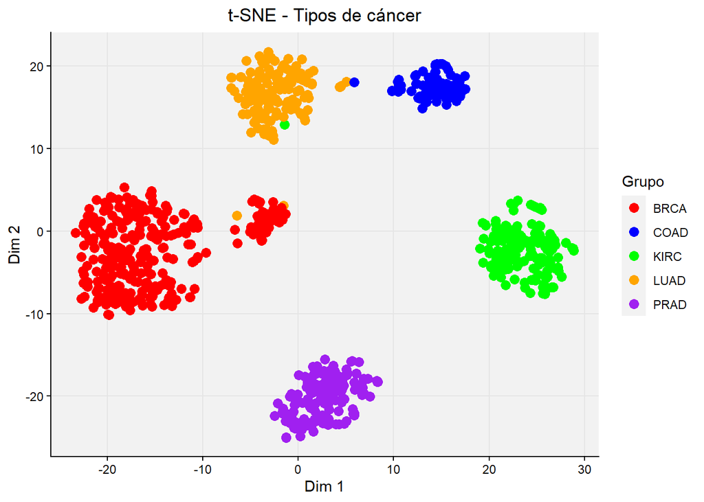

```r
# Directorio en donde tendremos nuestros datos

setwd("F:/UNIVERSIDAD/UNIR/BIOINFORMATICA/Algoritmos/ACTIVIDAD1")

# Carga de librerias

library(ggplot2)
library(Rtsne)
# Seteamos la semilla para que sea replicable el algoritmo

set.seed(1234)

# Lectura de datos

data.raw <- read.csv('data.csv')
labels.raw <- read.csv('labels.csv')

# Guardado en un dataframe de los 500 primeros genes

data <- sapply(data.raw[2:501], as.numeric)

# Algoritmo
# funcion Rtsne()
#   X: datos sobre los que reduciremos la dimensionalidad
#   dims: tamaño final del conjunto de datos (mejor <=3) por eficiencia
#   num_threads: hilos a utilizar (procesadores). No hace falta usarlo de momento
#
#   Variable Y con matriz del t-SNE

tsne <- Rtsne(X=data, dims=2)
tsne_result <- data.frame(tsne$Y)

# Graficamos
tsne_graf <- ggplot(tsne_result, aes(x = X1, y = X2, color = labels.raw$Class)) +
geom_point(size = 3) +
scale_color_manual(values = c("red", "blue", "green", "orange", "purple")) +
labs(title = "t-SNE - Tipos de cáncer", x = "Dim 1", y = "Dim 2", color = "Grupo") +
theme_classic() +
theme(panel.grid.major = element_line(color = "gray90"), panel.grid.minor = element_blank(),
panel.background = element_rect(fill = "gray95"), plot.title=element_text(hjust=0.5))

# Mostrar el gráfico

tsne_graf
```

La representación gráfica con t-SNE muestra una separación muy clara entre los diferentes tipos de cáncer (BRCA, COAD, KIRC, LUAD y PRAD). Esta separación es incluso más marcada que en PCA o MDS, lo cual es completamente esperable y coherente con el funcionamiento del algoritmo.

Biológicaménte tiene una fuerte coherencia, ya que cada tipo de cáncer tiene un perfil molecular único. Esto indica que hay patrones de expresión distintivos entre los tumores y señala que con este método se logra resaltar dichas diferencias formando clústeres bien definidos y separados.

## Método 4. Uniform Manifold Approximation and Projection (UMAP)

Para realizar la implementación de UMAP es necesario el uso de las librerías “uwot” y “ggplot2”.

El algoritmo UMAP es una de las técnicas más modernas y potentes para analizar datos de expresión génica. El motivo de elegirlo es la captura de relaciones no lineales entre las muestras, que es capaz de construir manifolds no lineales, preserva tanto la estructura local como la global, e identifica regiones densas y regiones de transición. Además, maneja muy bien datasets grandes y produce visualizaciones claras, suaves y biológicamente interpretables.

Los aspectos positivos de utilizar UMAP son la eficacia del método, su versatilidad a la hora de reducir la dimensionalidad, la efectividad del resultado para diversos tipos de datos, y que es menos costoso que otros métodos.

Pero tiene varios inconvenientes a tener en cuenta. UMAP dispone de muchos parámetros de asignación, lo que genera muchas combinaciones posibles y dificulta encontrar una proyección óptima. También, el coste computacional está relacionado con los parámetros utilizados y depende directamente de cuantos se usan. Además tiene un componente estocástico, pero las diferencias que puedan resultar en las distintas ejecuciones dan resultados casi idénticos.

Para poder realizar el análisis se han tenido los mismos problemas que con PCA, MDS y t-SNE respecto a la presencia de NA y 0, por lo que se han tomado las mismas medidas.

```r
# Directorio en donde tendremos nuestros datos

setwd("F:/UNIVERSIDAD/UNIR/BIOINFORMATICA/Algoritmos/ACTIVIDAD1")

# Carga de librerias

library(uwot)
```

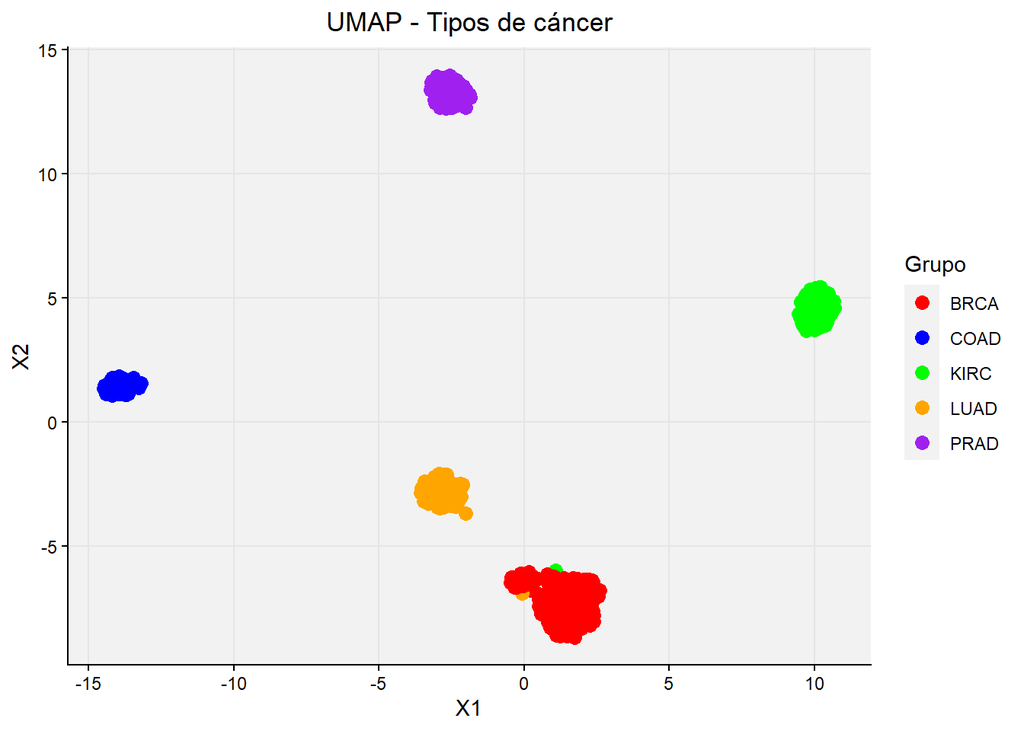

```r
library(ggplot2)

# Lectura de datos

data.red <- read.csv('data.csv')
labels.raw<- read.csv('labels.csv')

# Eliminamos la primera columna del archivo

data.raw <- data.red [, -1]

# Guardado en un dataframe de todos los genes

data <- sapply(data.raw, as.numeric)

# Se dejan los parametros a excepcion del n_neighbours

# Funcion umap()
#     x: reduccion de la dimensionalidad
#     n_neighbours: entero que indica el numero de vecinos cercanos
#     n_componentes: entero que determina el tamaño del espacio de salida
#     metric: define la distancia entre puntos
#     min_dist: distancia minima permitida entre puntos
#     local_conectivity: cuantos puntos están conectados "fuertemente"
#     scale: tipos de escalado
#     ret_model: para sacar los resultados del embedding
#     verbose: tiempo hasta que se complete el calculo

#     Y resultado


umap.results <- umap(data, n_neighbors=0.2 * nrow(data),
                     n_components = 2, min_dist = 0.1, local_connectivity=1,
                     ret_model = TRUE, verbose = TRUE)
umap.df <- data.frame(umap.results$embedding)

m_dist <- dist(umap.df)

# Graficamos

ggplot(umap.df, aes(x = X1, y = X2, color = labels.raw$Class)) +
  geom_point(size = 3) +
  scale_color_manual(values = c("red", "blue", "green", "orange", "purple")) +
  labs(title = "UMAP - Tipos de cáncer", x = "X1", y = "X2", color = "Grupo") +
  theme_classic() +
  theme(panel.grid.major = element_line(color = "gray90"), panel.grid.minor = element_blank(),
        panel.background = element_rect(fill = "gray95"), plot.title=element_text(hjust=0.5))
```

La representación gráfica con UMAP presenta un agrupamiento claro de todos los puntos por tipo de cáncer, estableciendo clusters compactos con una forma y densidad relativamente uniformes, y con una separación muy clara de cada uno de ellos respecto al resto.

El resultado obtenido tiene totalmente sentido biolóbico. La clara separación entre las variables es coherente y esperada, ya que cada tipo de cáncer tiene un perfil molecular característico. Además, el algoritmo es muy bueno separando grupos heterogéneos, por lo que si las variables son realmente distintas, la proyección las separa de manera marcada, tal y como ocurre con estos datos.

También se observa que los grupos BRCA y LUAD aparecen más cercanos, pudiendo indicar que la expresión de estos tipos de cáncer comparten alguna ruta molecular.